# 02056823

Time Series Coursework

CID: 02056823

```python
import numpy as np
import matplotlib.pyplot as plt
```

Q1

1(a)

For an AR(4) process, the characteristic equation is:

$$1 - \phi_{1,4} z - \phi_{2,4} z^2 - \phi_{3,4} z^3 - \phi_{4,4} z^4 = 0$$ with the following roots: \begin{align*} z_{1} &= r_1 e^{i\theta_1}, \quad z_{1}^* = r_1 e^{-i\theta_1}, \\ z_{2} &= r_2 e^{i\theta_2}, \quad z_{2}^* = r_2 e^{-i\theta_2}. \end{align*} Where \begin{align*} \theta_1 &= 2 \pi f_1, \\ \theta_2 &= 2 \pi f_2. \end{align*}

The characteristic polynomial is given by the product of the factors for each root: \begin{equation*} (1 - z_1 B)(1 - z_1^* B)(1 - z_2 B)(1 - z_2^* B) = 1 - \phi_1 B - \phi_2 B^2 - \phi_3 B^3 - \phi_4 B^4, \end{equation*} where ( B ) is the backshift operator.

Expanding this product gives coefficients for the AR(4) process: \begin{align*} \phi_1 &= 2 r_1 \cos(2 \pi f_1) + 2 r_2 \cos(2 \pi f_2), \\ \phi_2 &= -r_1^2 - 4 r_1 r_2 \cos(2 \pi f_1) \cos(2 \pi f_2) - r_2^2, \\ \phi_3 &= 2 r_1 r_2 (r_1 \cos(2 \pi f_2) + r_2 \cos(2 \pi f_1)), \\ \phi_4 &= -r_1^2 r_2^2. \end{align*} The code for constructing such AR(4) process given inputs f1, f2, r1, r2, N and $\sigma^2_\epsilon$ are given:

```python
def simulate_AR4(N, f1, f2, r1, r2, sigma2_e):
    phi_1 = 2 * r1 * np.cos(2 * np.pi * f1) + 2 * r2 * np.cos(2 * np.pi * f2)
    phi_2 = -(r1**2 + r2**2 + 4*r1*r2*np.cos(2*np.pi*f1)*np.cos(2*np.pi*f2))
    phi_3 = 2*(r1**2 * r2)*np.cos(2*np.pi*f2) + 2*(r1 * r2**2)*np.cos(2*np.pi*f1)
    phi_4 = -(r1**2)*(r2**2)
    burn_in = 1000

    # Initialize the time series array with zeros
    total = N+burn_in
    X = np.zeros(total)
    e = np.random.normal(0, np.sqrt(sigma2_e), total)

    # Generate the AR(4) process
    for t in range(4, total-1):
        X[t] = phi_1 * X[t-1] + phi_2 * X[t-2] + phi_3 * X[t-3] + phi_4 * X[t-4] + e[t]
    X = X[burn_in:]
    return X, (phi_1, phi_2, phi_3, phi_4)
```

1(b)

```python
import numpy as np

def S_AR(f, phis, sigma2):
    p = len(phis)
    f = np.asarray(f)
    phis = np.asarray(phis)

    # Compute the spectral density
    spectral_density = np.zeros_like(f, dtype=complex)
    for i, freq in enumerate(f):
        denominator = 1 - np.sum(phis * np.exp(-2j * np.pi * freq * np.arange(1, p + 1)))
        spectral_density[i] = sigma2 / (abs(denominator)**2)

    return spectral_density.real
```

1(c)

```python
from numpy.fft import fft, fftfreq, fftshift

def periodogram(x):
    n = len(x)
    X = fft(x)

    Pxx = (1/n) * np.abs(X)**2 # power spectral density (periodogram)
    freq = fftfreq(n) # Fourier frequencies

    # Shift both the frequencies and the periodogram
    f = fftshift(freq)
    Pxx = fftshift(Pxx)

    return f, Pxx
```

```python
def direct(X, p):
    n = len(X)
    taper = np.ones(n)
    # build cosine taper
    for t in range(1, n + 1):
        if t <= np.floor(p * n) / 2:
            taper[t - 1] = 1 / 2 * (1 - np.cos(2 * np.pi * t / (np.floor(p * n) + 1)))
        elif t > np.floor(p * n) / 2 and t < n + 1 - np.floor(p * n) / 2:
            taper[t - 1] = 1
        else:
            taper[t - 1] = 1 / 2 * (1 - np.cos(2 * np.pi * (n + 1 - t) / (np.floor(p * n) + 1)))

    taper /= np.linalg.norm(taper)  # normalizing the taper
    X_tapered = X * taper
    X_fft = fft(X_tapered)

    # compute the power spectral density
    Pxx_direct = np.abs(X_fft)**2
    return fftshift(Pxx_direct)
```

1(d)

A & B:

```python
rvals = np.arange(0.8, 1.0, 0.01)
freq = np.array([6/64, 8/64, 16/64, 26/64])
tapers = [0.05, 0.1, 0.25, 0.5]
freq_keys = ["bias at 6/64,", "bias at 8/64", "bias at 16/64", "bias at 26/64"]
taper_keys = ["p = 0.05", "p = 0.1", "p = 0.25", "p = 0.5"]
def part1D(r):
    N, f1, f2, sigma2_e, num = 64, 6/64, 26/64, 1, 5000
    r1 = r2 = r

    perio_values = np.zeros((num, len(freq)))
    dse = np.zeros((num, len(tapers), len(freq))) # direct spectral estimates
    spectra = np.zeros((num, len(freq)))

    for i in range(num):
        X, phi = simulate_AR4(N, f1, f2, r1, r2, sigma2_e)
        _, Pxx = periodogram(X)
        perio_values[i, :] = Pxx[np.isin(_, freq)] # store periodogram

        # Compute direct spectral estimates with different taper percentages
        for j, p in enumerate(tapers):
            Pxx_direct = direct(X, p)

            # Store the direct spectral estimate values for the specified frequencies
            dse[i, j, :] = Pxx_direct[np.isin(_, freq)]

        spectra[i, :] = S_AR(freq, phi, sigma2_e)  # theoretical sdf

    # build a dict to store bias for periodogram at diff bias
    bias_periodogram = np.mean((perio_values - spectra) / spectra * 100, axis=0)
    bias_periodogram = dict(zip(freq_keys, bias_periodogram))

    # build a dict to store bias for direct at diff bias within diff p
    bias_direct = np.mean((dse - spectra[:, np.newaxis, :]) / spectra[:, np.newaxis, :] * 100, axis=0)
    bias_direct_list = []
    for i in range(len(tapers)):
        bias_direct_list.append(dict(zip(freq_keys, bias_direct[i, :])))
    bias_direct = dict(zip(taper_keys, bias_direct_list))
    return bias_periodogram, bias_direct
part1D(rvals[0]) # example on r = 0.8
```

```
({'bias at 6/64,': -8.943447364815906,
  'bias at 8/64': 3.7985162594003565,
  'bias at 16/64': 7.616468011201503,
  'bias at 26/64': -9.356826339085062},
 {'p = 0.05': {'bias at 6/64,': -7.680073232853268,
   'bias at 8/64': 4.975778560123771,
   'bias at 16/64': 6.941591058495437,
   'bias at 26/64': -8.312598474672209},
  'p = 0.1': {'bias at 6/64,': -7.078506718815267,
   'bias at 8/64': 5.483557644340685,
   'bias at 16/64': 4.825589814195846,
   'bias at 26/64': -7.850887637350902},
  'p = 0.25': {'bias at 6/64,': -6.182132939015975,
   'bias at 8/64': 6.42034885116753,
   'bias at 16/64': 0.814699878635122,
   'bias at 26/64': -7.301075498479451},
  'p = 0.5': {'bias at 6/64,': -5.297085938680749,
   'bias at 8/64': 7.211406024875002,
   'bias at 16/64': -0.6483714064590498,
   'bias at 26/64': -6.790824203902899}})
```

1(d)

C & D:

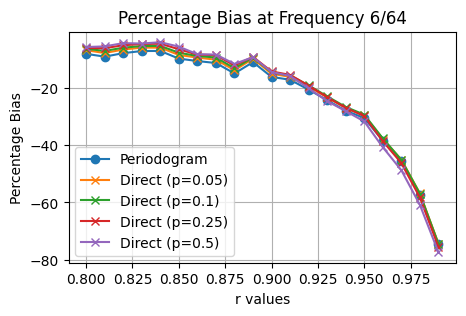

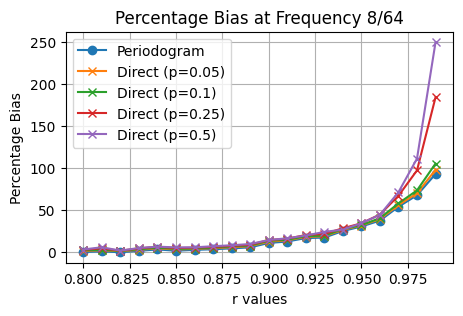

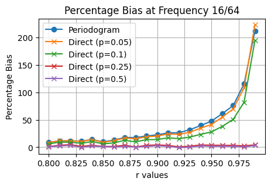

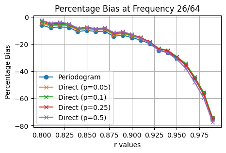

```python
freq = np.array([6/64, 8/64, 16/64, 26/64])
tapers = [0.05, 0.1, 0.25, 0.5]
rvals = np.arange(0.8, 1.0, 0.01)
results = [part1D(r) for r in rvals] # apply part1D for all r = 0.81... 0.99
for i, f in enumerate(freq):
    periodogram_biases = [results[j][0][freq_keys[i]] for j in range(len(rvals))]
    plt.figure(figsize=(5, 3))
    # make sure title is fraction not decimal
    plt.title(f'Percentage Bias at Frequency {int(f*64)}/64')
    plt.xlabel('r values')
    plt.ylabel('Percentage Bias')
    plt.plot(rvals, periodogram_biases, label='Periodogram', marker='o') # plot bias percentage

    # Plot direct estimator biases for each p
    for k in range(len(tapers)):
        direct_biases = [results[j][1][taper_keys[k]][freq_keys[i]] for j in range(len(rvals))]
        plt.plot(rvals, direct_biases, label=f'Direct (p={tapers[k]})', marker='x')

    plt.legend()
    plt.grid(True)
    plt.show()
```

1(e)

Comments about the plots:

Q2

My data is from 1935.125 (1935.4) to 1945.042 (1945.2). I removed the mean, then called $direct()$ at $p=0.25$ for my spectrum.

Removing the mean is necessary, as the presence of a non-zero mean can introduce a bias. The mean of the time series contributes a spike at zero frequency, and our spectral analysis is only meaningful with stationary assumption, as that makes sure autocovariance is based on deviation from the mean.

The dominant frequencies are $\pm$ 0.02 and $\pm$ 0.08, as plotted by the following code. A dominant frequency of $\pm$ 0.08 $month^{-1}$, or $\frac{1}{12 month}$, suggests an annual cycling trend. A dominant frequency of $\pm$ 0.02 $month^{-1}$, or $\frac{1}{48 month}$, suggests a trend of the tides repeating itself every 4 years

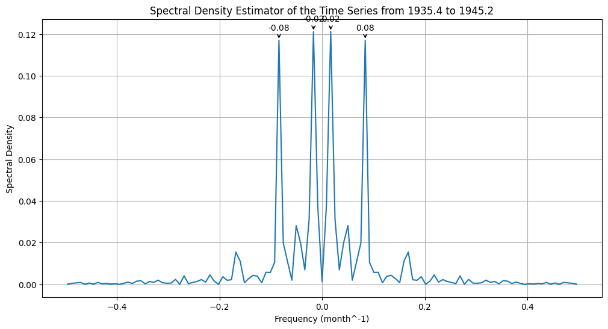

```python
import pandas as pd
data = pd.read_csv("0318.csv")
# print(data.head())
time_series = data.iloc[:, 1]
time_mean = np.mean(time_series)
time_series = time_series- time_mean # remove mean

freq, _ = periodogram(time_series) # obtain frequenties
direct_spectrum = direct(time_series, 0.25)
# normalize sdf
direct_spectrum = direct_spectrum * (1 / np.sum(direct_spectrum))
# by plotting, I can identify 4 peaks. the following code labels these 4 peaks
indices = np.argsort(direct_spectrum)[-4:]
dominant_freqs = freq[indices]
plt.figure(figsize=(12, 6))
plt.plot(freq, direct_spectrum)
plt.title('Spectral Density Estimator of the Time Series from 1935.4 to 1945.2')
plt.xlabel('Frequency (month^-1)')
plt.ylabel('Spectral Density')
# annotate the plot to show values of peak frequency:
for i in indices:
    peak_freq = freq[i]
    peak_value = direct_spectrum[i]
    plt.annotate(f'{peak_freq:.2f}',
                 xy=(peak_freq, peak_value),
                 xytext=(0, 15),  # Adjusting text position to be above the peak
                 textcoords='offset points',
                 ha='center',
                 va='center',
                 arrowprops=dict(facecolor='black', arrowstyle='->'))
plt.grid(True)
plt.show()
```

Q3

3(a)

```python
import numpy as np

def yw(time_series, p):
    def autocorrelation(time_series, lag):
        n = len(time_series)
        mean = np.mean(time_series)
        autocorr = np.sum((time_series[:n-lag] - mean) * (time_series[lag:] - mean))
        autocorr /= np.sum((time_series - mean) ** 2)
        return autocorr
    R = np.array([autocorrelation(time_series, lag) for lag in range(p+1)])
    R_matrix = np.array([R[abs(i-j)] for i in range(1, p+1) for j in range(1, p+1)]).reshape(p, p)
    R_vector = R[1:p+1]
    return np.linalg.solve(R_matrix, R_vector)

def AMLE(X, p):
    ''' Approximate maximum likelihood estimation scheme.'''
    N = len(X)
    # Construct matrix F
    # phi = (F^TF)-1 * F^T X
    F = np.zeros((N-p, p)) # Toeplitz matrix F
    for i in range(p, N):
        F[i-p, :] = X[i-p:i][::-1]
    X_vector = X[p:]
    phi_hat = np.linalg.inv(F.T @ F) @ F.T @ X_vector
    sigma2 = ((X_vector - F @ phi_hat).T @ (X_vector - F @ phi_hat)) / (N - p)
    return phi_hat, sigma2
```

```python
data = pd.read_csv("0318.csv", header= None)
time_series = data.iloc[:, 1].values # turn pd into np array
for p in range(1, 11):
    SE = np.array([]) # squared errors for yw
    SE2 = np.array([]) # squared errors for MLE
    for i in range(60, 120):
        train_data = time_series[:i]
        train_mean = np.mean(train_data)
        train_data = train_data - train_mean # remove mean

        actual = time_series[i]
        # yw
        phi = yw(train_data, p)
        Xi = np.dot(phi[::-1], train_data[-p:]) + train_mean # add mean back
        SE = np.append(SE, (Xi - actual)**2)
        # print("phi", phi, f"X{i+1}", Xi, actual)

        # AMLE
        phi, sig = AMLE(train_data, p)
        Xi = np.dot(phi[::-1], train_data[-p:]) + train_mean # add mean back
        SE2 = np.append(SE2, (Xi - actual)**2)
    RMSE = np.sqrt(np.mean(SE))
    RMSE2 = np.sqrt(np.mean(SE2))
    print("p=",p, "RMSE for yule-walker", RMSE, "RMSE for MLE", RMSE2)
```

```
p= 1 RMSE for yule-walker 64.6448594177241 RMSE for MLE 63.61085401427229
p= 2 RMSE for yule-walker 63.60521989677166 RMSE for MLE 61.646183152357985
p= 3 RMSE for yule-walker 63.92935429911002 RMSE for MLE 62.41290755692409
p= 4 RMSE for yule-walker 64.73459596306994 RMSE for MLE 63.54411290536228
p= 5 RMSE for yule-walker 65.00959724474352 RMSE for MLE 64.40155805711167
p= 6 RMSE for yule-walker 66.03010443458422 RMSE for MLE 65.44709265412563
p= 7 RMSE for yule-walker 66.57206324016981 RMSE for MLE 66.7339395409737
p= 8 RMSE for yule-walker 66.56554719330079 RMSE for MLE 66.79660945091398
p= 9 RMSE for yule-walker 67.49667015934021 RMSE for MLE 68.77383995167027
p= 10 RMSE for yule-walker 66.70727752194941 RMSE for MLE 66.22996524757627
```

p = 2 leads to the lowest RMSE for both yule-walker and MLE method (63.605 and 61.646)

3(b)

```
phi [ 1.02243154 -0.26677428]
```

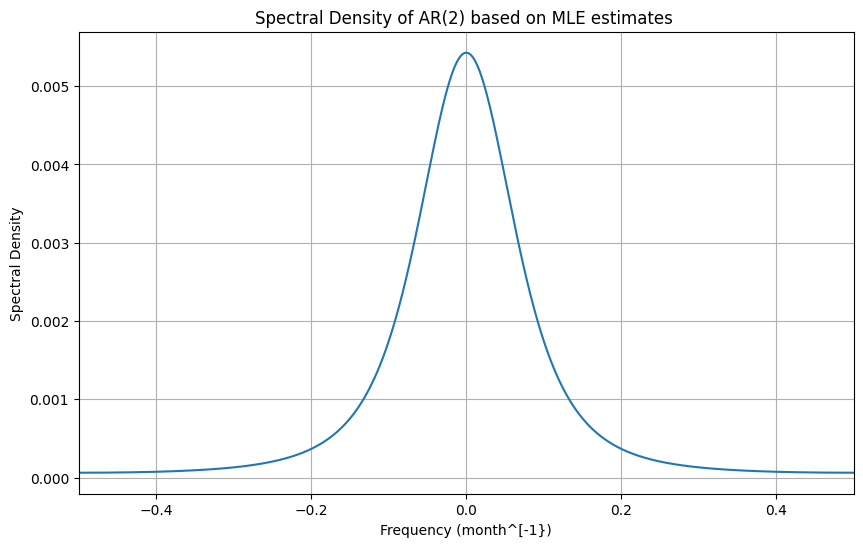

```python
data = pd.read_csv("0318.csv", header= None)
time_series = data.iloc[:, 1].values # turn pd into np array
time_series = time_series - np.mean(time_series)
phi, sig = AMLE(time_series, 2) # estimate phi based on p=2
print("phi", phi)
f = np.linspace(-0.5, 0.5, 1000)
sdf = S_AR(f, phi, sig) # spectral estimate
sdf = sdf / np.sum(sdf)
plt.figure(figsize=(10, 6))
plt.plot(f, sdf)
plt.title('Spectral Density of AR(2) based on MLE estimates ')
plt.xlabel('Frequency (month^[-1})')
plt.ylabel('Spectral Density')
plt.grid(True)
plt.xlim(-0.5,0.5)
plt.show( )
```

3(c)

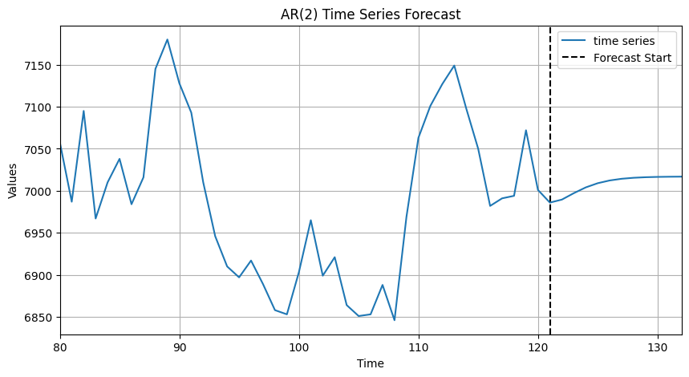

```python
p = 2
data = pd.read_csv("0318.csv", header= None)
time_series = data.iloc[:, 1].values # turn pd into np array
time_mean = np.mean(time_series)
time_series = time_series - time_mean # stationary time series
phi, _ = AMLE(time_series, 2) # from 3(b) we have found phi = [1.02243154, -0.26677428]
Xt =  time_series[79:] # for storing X80...X132
for _ in range(12):
    forecast = phi[0] * Xt[-1] + phi[1] * Xt[-2]
    Xt = np.append(Xt, forecast)

plt.figure(figsize=(10, 5))
plt.plot(range(80, 133), Xt + time_mean, label="time series") # add mean back
plt.axvline(x=121, color='black', linestyle='--', label='Forecast Start')
plt.title('AR(2) Time Series Forecast')
plt.xlabel('Time')
plt.ylabel('Values')
plt.legend()
plt.grid(True)
plt.xlim(80, 132)
plt.show()
```

3(d)

Having chosen p = 2, with $\phi$ given by (1.02243154 -0.26677428) from 3(b) using MLE

We fit AR(2) to predict X3, ...., X120 and calculate $\xi_3 .... \xi_{120}$

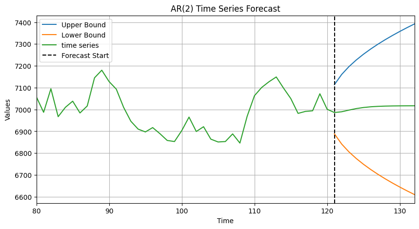

```python
data = pd.read_csv("0318.csv", header= None)
# data = pd.read_csv("0299.csv", header= None)
time_series = data.iloc[:, 1].values # turn pd into np array
phi = np.array([1.02243154, -0.26677428]) # obtained from 3(b)
p = 2 # obtained from 3(a)
l = np.arange(1, 13) # l=1 for x121 ... l=12 for x132
residuals = np.array([])
for i in range(3, 120):
    actual = time_series[i]
    Xi = np.dot(phi[::-1], time_series[i-p:i]) # l = 1
    residuals = np.append(residuals, (Xi - actual))
ssd = np.std(residuals, ddof=1) # sample standard deviation of residuals
# print(ssd) # around 57
# obtain 95% CI based on X(120+l) +- 1.96*ssd*sqrt(l):
UB, LB = time_series[-1] + ssd*1.96*np.sqrt(l), time_series[-1] - ssd*1.96*np.sqrt(l)

plt.figure(figsize=(10, 5))
plt.plot(range(121, 133), UB, label='Upper Bound' )
plt.plot(range(121, 133), LB, label='Lower Bound' )
plt.plot(range(80, 133), Xt + time_mean, label="time series") # add mean back
plt.axvline(x=121, color='black', linestyle='--', label='Forecast Start')
plt.title('AR(2) Time Series Forecast')
plt.xlabel('Time')
plt.ylabel('Values')
plt.legend()
plt.grid(True)
plt.xlim(80, 132)
plt.show()
```

3(e)

I calculated RMSE on p = 11...20:

```python
data = pd.read_csv("0318.csv", header= None)
time_series = data.iloc[:, 1].values # turn pd into np array
for p in range(11, 21):
    SE = np.array([]) # squared errors for yw
    SE2 = np.array([]) # squared errors for MLE
    for i in range(60, 120):
        train_data = time_series[:i]
        train_mean = np.mean(train_data)
        train_data = train_data - train_mean # remove mean

        actual = time_series[i]
        # yw
        phi = yw(train_data, p)
        Xi = np.dot(phi[::-1], train_data[-p:]) + train_mean # add mean back
        SE = np.append(SE, (Xi - actual)**2)
        # print("phi", phi, f"X{i+1}", Xi, actual)

        # AMLE
        phi, sig = AMLE(train_data, p)
        Xi = np.dot(phi[::-1], train_data[-p:]) + train_mean # add mean back
        SE2 = np.append(SE2, (Xi - actual)**2)
    RMSE = np.sqrt(np.mean(SE))
    RMSE2 = np.sqrt(np.mean(SE2))
    print("p=",p, "RMSE for yule-walker", RMSE, "RMSE for MLE", RMSE2)
```

```
p= 11 RMSE for yule-walker 66.78766703465959 RMSE for MLE 66.97162136749503
p= 12 RMSE for yule-walker 67.0551554066414 RMSE for MLE 67.19348141966901
p= 13 RMSE for yule-walker 67.04123081183553 RMSE for MLE 64.99820443671068
p= 14 RMSE for yule-walker 66.54603540060884 RMSE for MLE 64.7339665534013
p= 15 RMSE for yule-walker 66.40100982406828 RMSE for MLE 64.86152481107911
p= 16 RMSE for yule-walker 66.84726839404401 RMSE for MLE 65.76695166659513
p= 17 RMSE for yule-walker 67.39087420070537 RMSE for MLE 66.49061131463995
p= 18 RMSE for yule-walker 67.68008954849611 RMSE for MLE 67.74726244017003
p= 19 RMSE for yule-walker 67.42272079216023 RMSE for MLE 68.26339536398393
p= 20 RMSE for yule-walker 67.42064421897801 RMSE for MLE 67.52726965073187
```